# 170111 Analysis of E Cell Antag Screen

This is the third attempt to run a antagonist screen with the newly optimized E cells to make sure that H3A cells and E Cells show similar responses to odors. This run was different becuase a new aloquat of TMA was made and the antag odor block was diluted from the stock (instead of using an older dilution). In addition many extra TMA alone (or forskolin alone) wells were run throughout the plate (specifically in all of column 12 and all of row J). This will help us observe any plate effects that may be influencing these experiments.

Inhibition rankings of trans-2-nonen-1-ol (821) and Linalool (827, control odor).

```
##     PlateNum CloneKey Odor1K Odor2K Odor1C Odor2C PlateLocation LucData
## 997        2      830    817    827      0      0           E15    3829
## 969        2      830    817    821      0      0           I13    3795
##     RLData CellType TransfectionType     norm    PerAg  PerInhib rankInhib
## 997   2355  E Cells     antag screen 1.625902 84.30325 15.696747        67
## 969   2042  E Cells     antag screen 1.858472 96.36203  3.637975       152
```

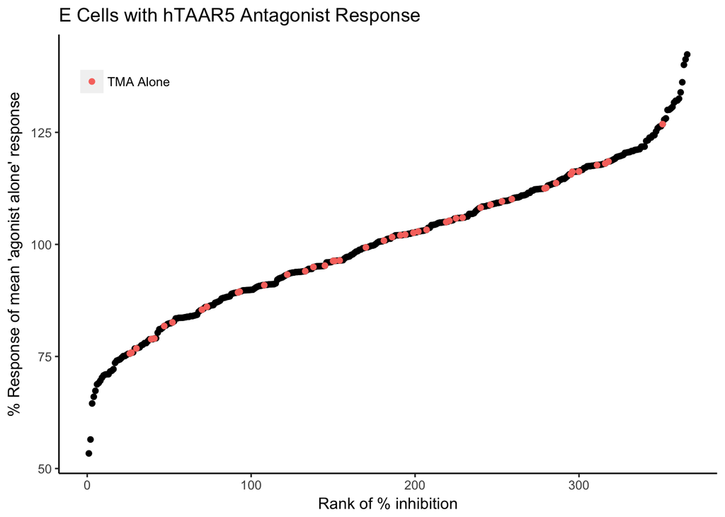

The agonist alone control (TMA alone) is not at all consistent (pink dots). Let us look at the H3A plate with hTAAR5 and TMA to see if we observe a similar effect.

%Inhibition rankings of trans-2-nonen-1-ol (821) and the control Linalool(827)

```
##     PlateNum CloneKey Odor1K Odor2K Odor1C Odor2C PlateLocation LucData
## 613        4      830    817    827      0      0           E15    3081
## 585        4      830    817    821      0      0           I13    2768
##     RLData CellType TransfectionType     norm     PerAg  PerInhib
## 613   2256      H3A     antag screen 1.365691  84.36302 15.636977
## 585   1561      H3A     antag screen 1.773222 109.53747 -9.537472
##     rankInhib
## 613        81
## 585       268
```

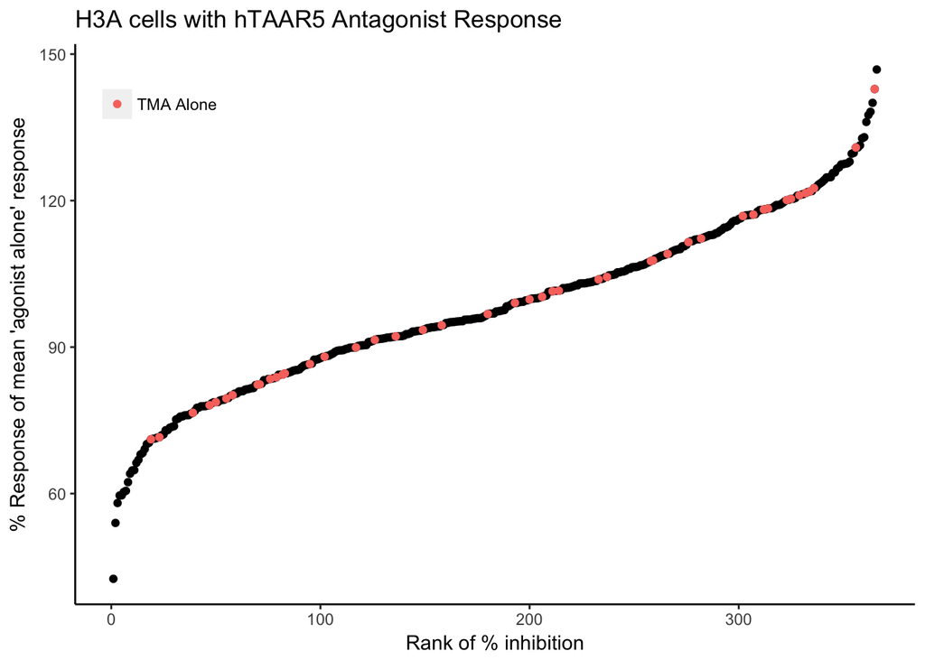

The H3A TMA responses are also very inconsistent. It is likely that we are seeing some sort of plate effect.

# Examining Plate Effects

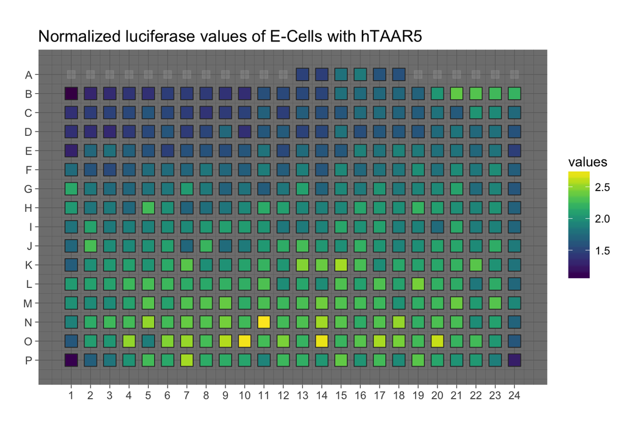

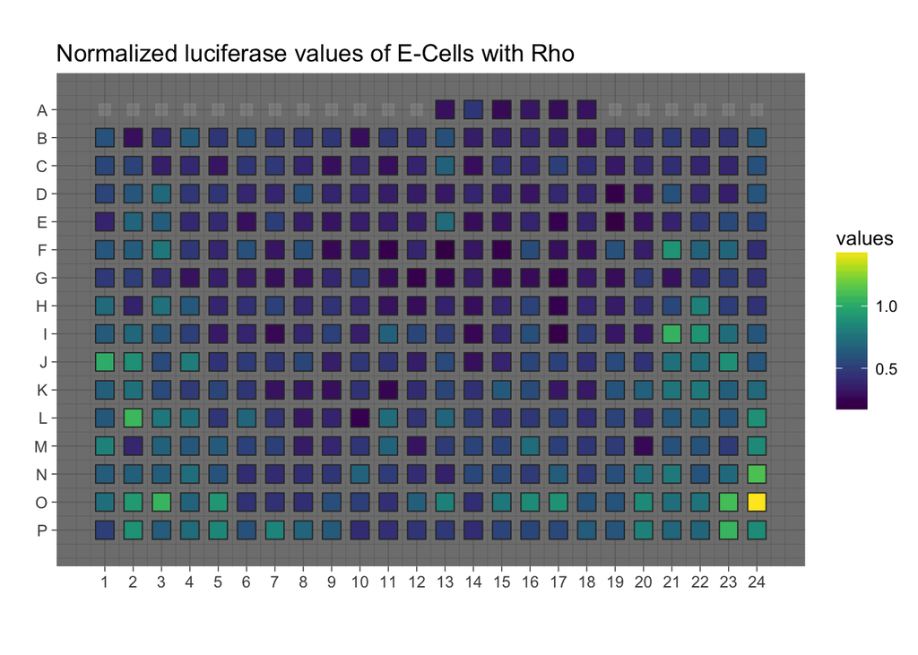

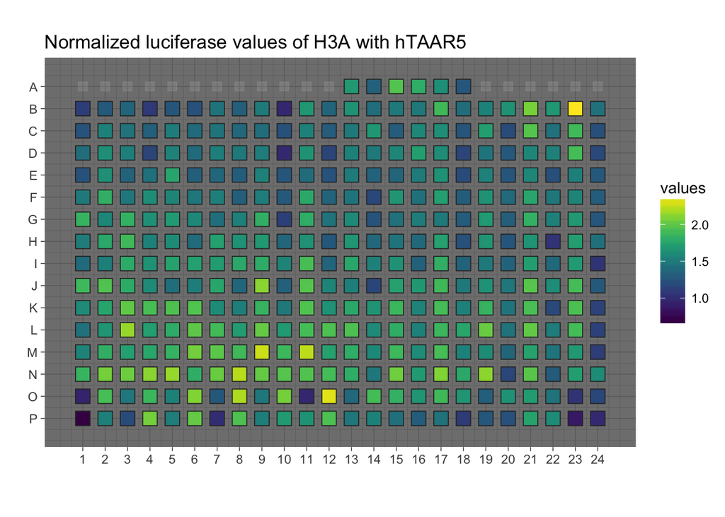

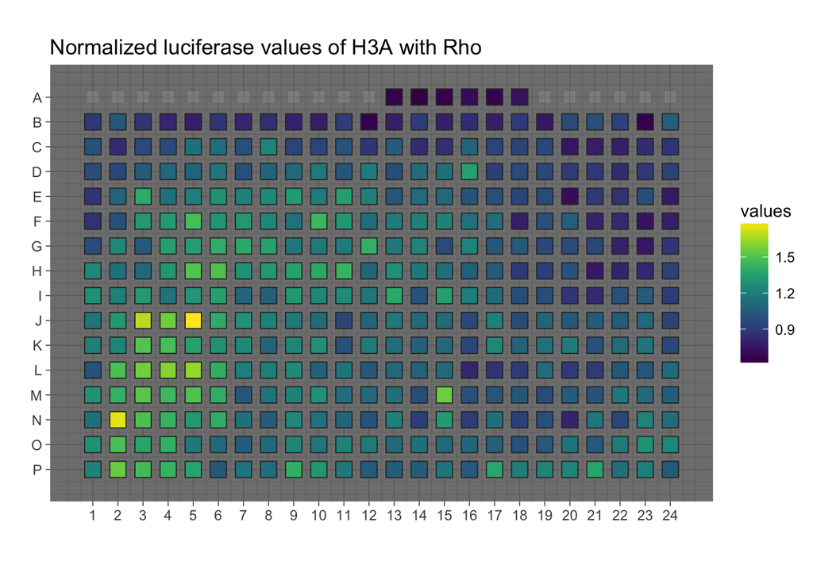

The heat map of E cells with hTAAR5 (top) shows a very clear gradient with increasing activation down the plate from A to P. This is especially evident when you focus on the TMA alone in column 12. The other plates do not show as obvious a gradient. Since this is looking at normalized values, I will next examine whether the luciferase or RL values are the cause of this gradient.

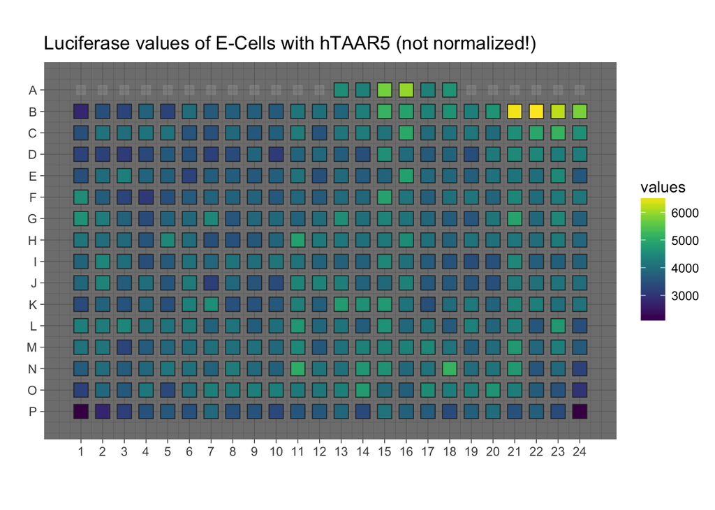

The luciferase does not show any obvious pattern or gradient.

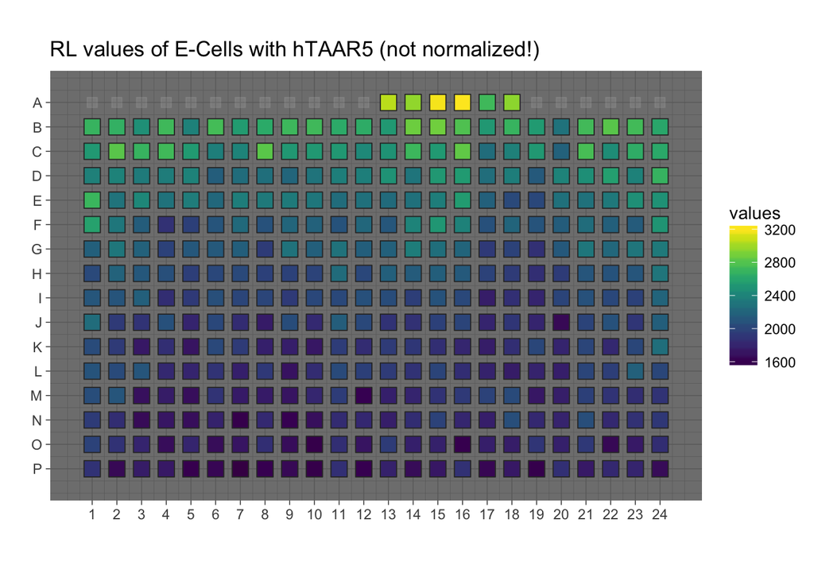

RL values show a clear gradient with high reads on the top of the plate to lower reads on the bottom (because normalized data divides by RL, this is why we see the opposite gradient on the normalized plate).

Interestingly, and frightenly, we see the same RL gradient on each of the other plates of this run.

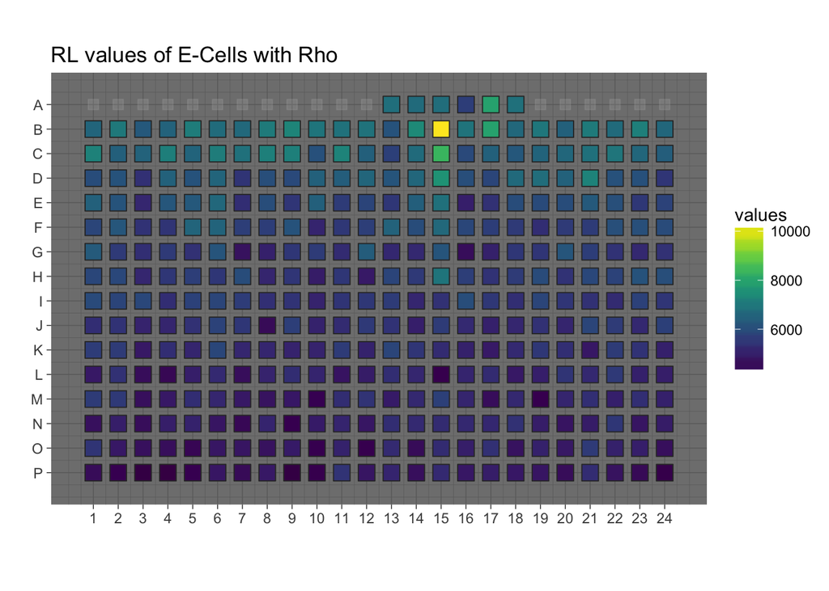

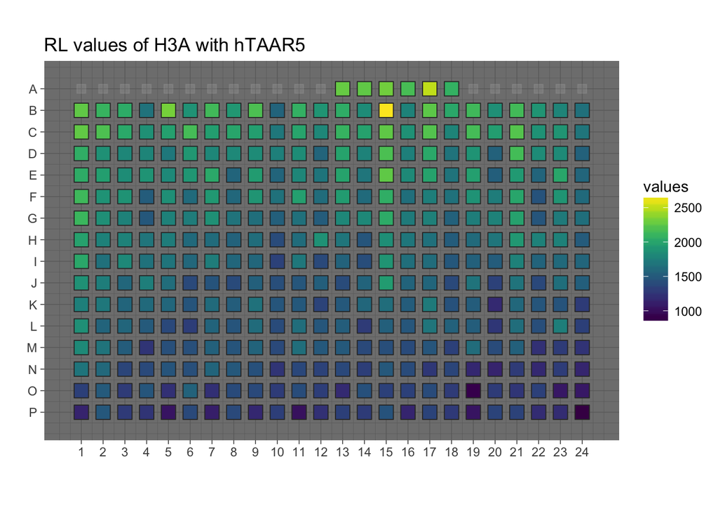

[figure not shown]

Why are we seeing this gradient of RL, and is it on other run of 384 plates?

To examine this further, I will look at the last two antag screens and see if the RL values show the same gradient.

# Examine previous Antag screens for RL gradient

For the screen on 11-4-16

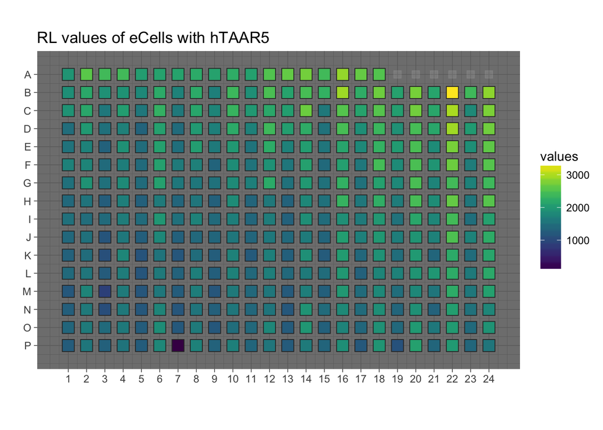

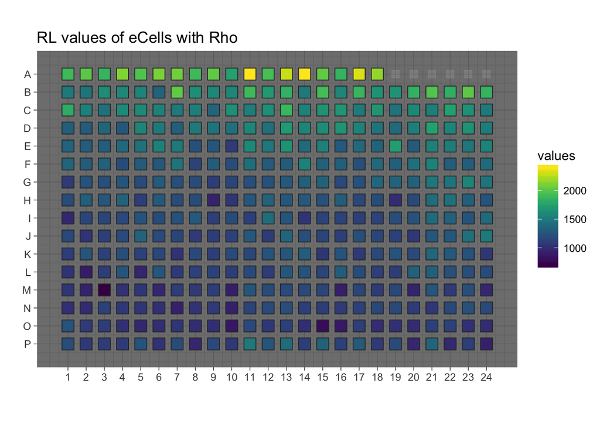

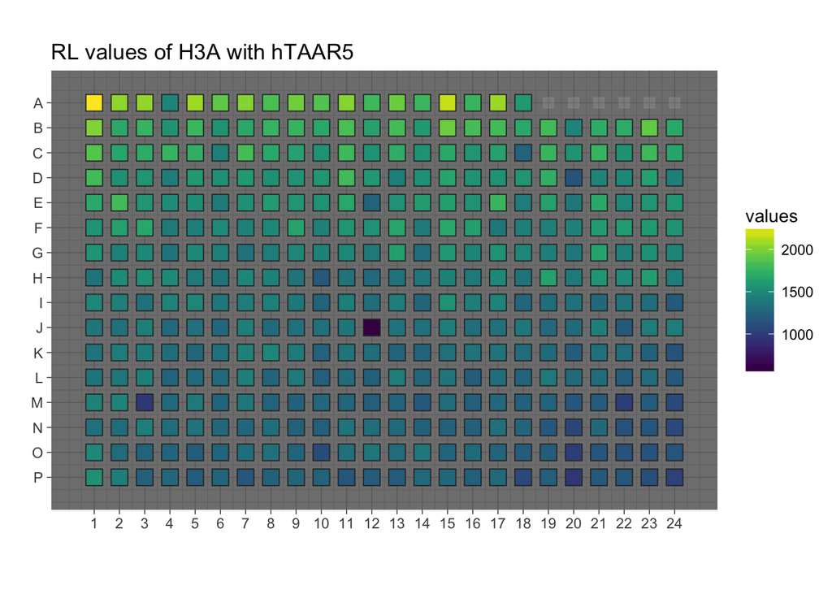

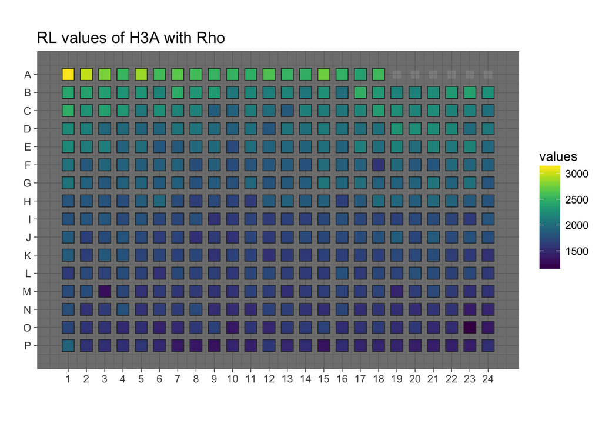

Examine Run from 10/1/16 for RL pattern

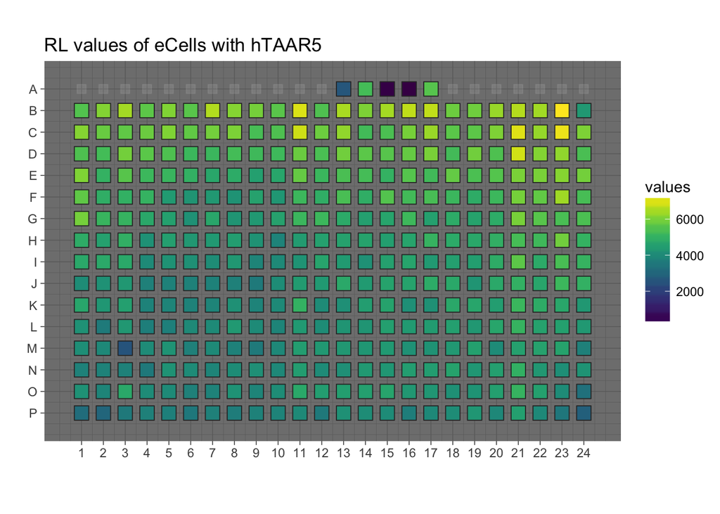

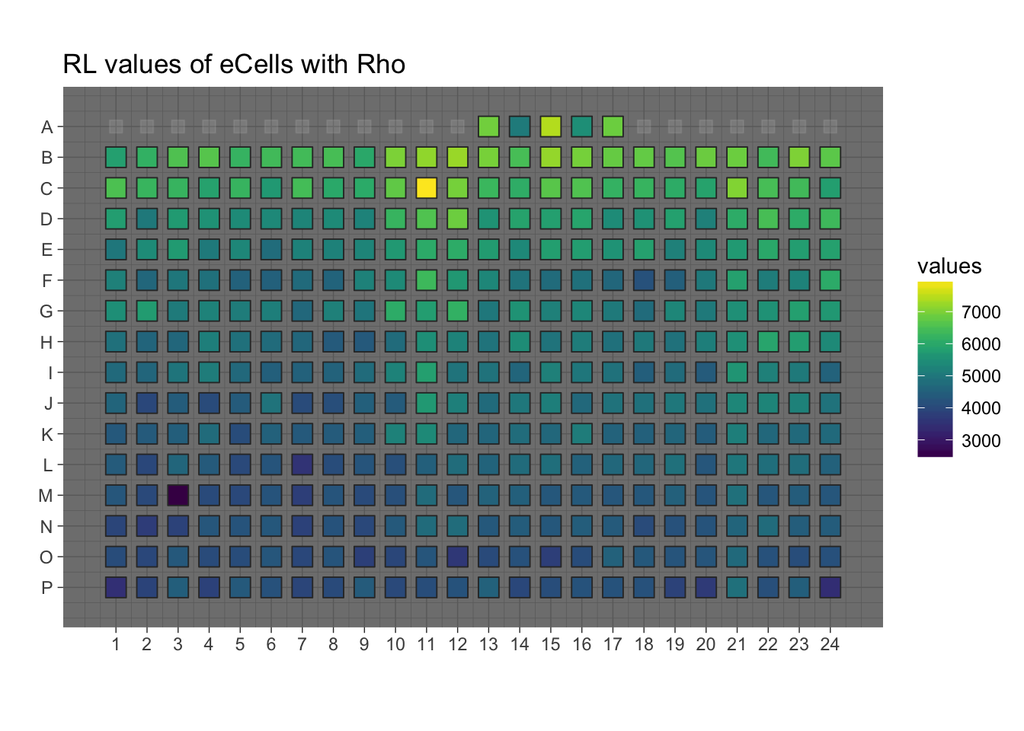

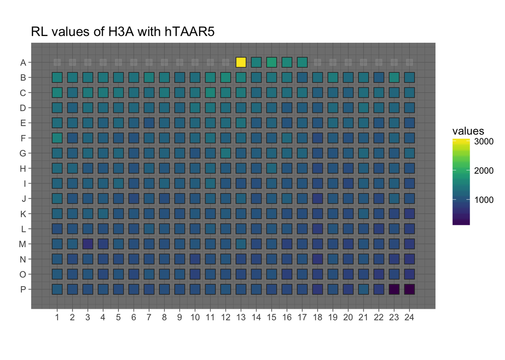

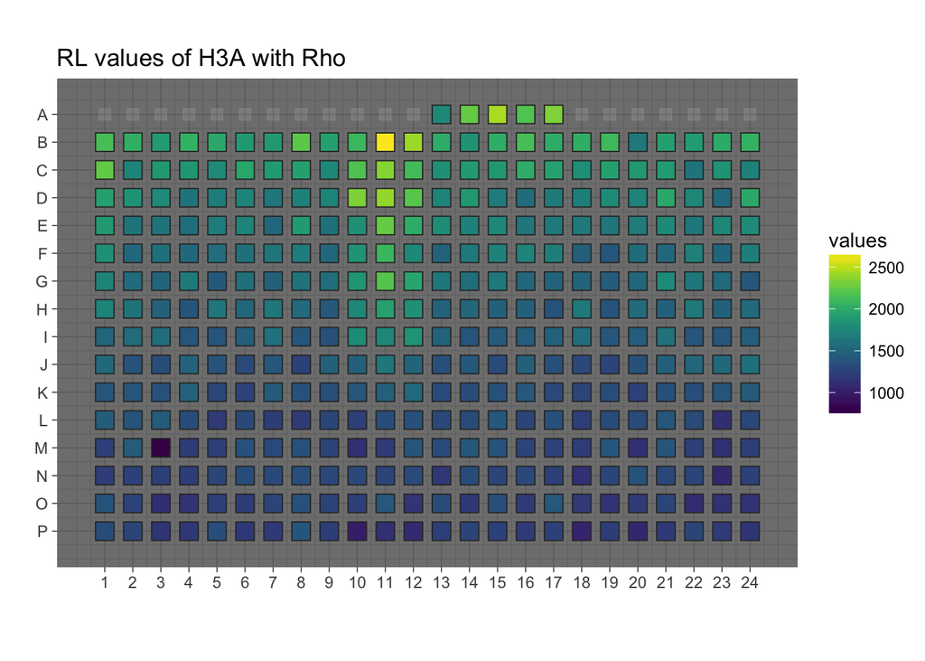

This explains the unusual result I have been seeing in these runs. In all previous experiments, the TMA alone has had the lowest normalized luciferase value, even compared to potential antagonists. The TMA alone wells have always been at the top of the plate, meaning that becuase RL is highest there, the normalized value is lowest.

Why does the RL show this gradient? should I analyze these plates based on luciferase alone? Should I find a way to normalize the plates that takes the RL gradient into account?